# Predictive Machine Learning

Eric M. Jalbert

June 21, 2015

## Introduction

This is a write-up for the predictive machine learning project. The first step is to load up the training and testing data sets and libraries.

```r
training <- read.csv("pml-training.csv", na.strings = c("NA", ""))
testing <- read.csv("pml-testing.csv", na.strings = c("NA", ""))
```

```r
library(caret)
```

```r
library(rpart)
library(rpart.plot)
library(randomForest)
```

Also, for reproducibility;

```r
set.seed(6615)
```

## Data Pre-processing

There are a number of variables that are not needed in the predictive model. These are the one that do not represent any movement. These can be removed.

```r
training <- training[, -(1:7)]
```

```r
training <- training[ , colSums(is.na(training)) == 0]
```

## Cross Validation

```r
i <- createDataPartition(y = training$classe, p = 0.2, list = FALSE)
small_training<- training[i, ]
small_testing <- training[-i, ]
```

## Model Building

### Decision Trees

We can quickly build the tree using the following commands. We can also get a visual look at it.

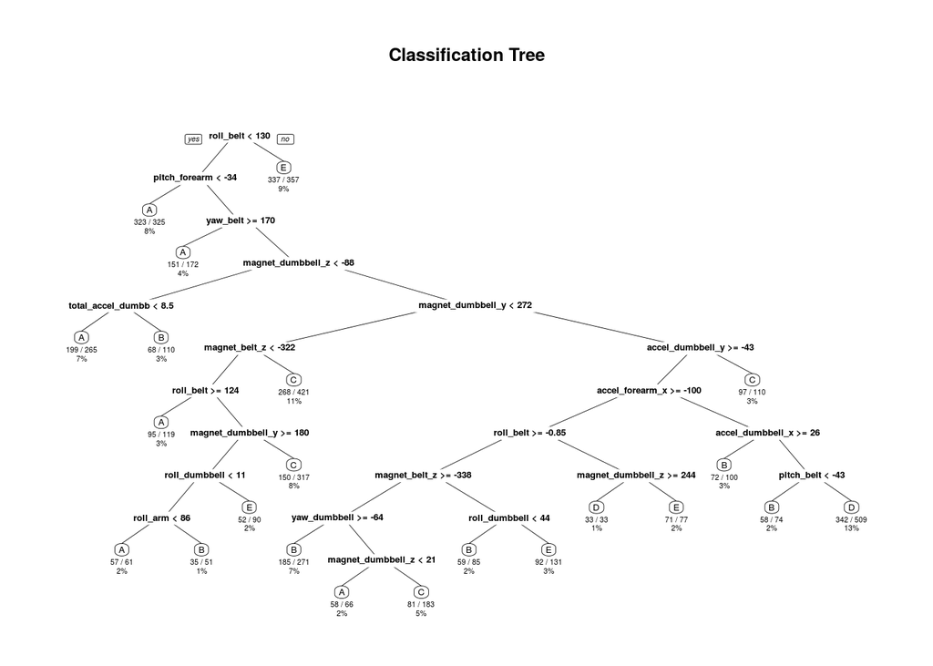

```r
deciTree <- rpart(classe ~ ., data=small_training, method="class")
predictionTree <- predict(deciTree, small_testing, type = "class")
rpart.plot(deciTree, main="Classification Tree", extra=102, under=TRUE, faclen=0)
```

Now we can test out this model on our smaller testing set to see how it rates.

```r
confusionMatrix(predictionTree, small_testing$classe)
```

```
## Confusion Matrix and Statistics
##
##           Reference
## Prediction    A    B    C    D    E
##          A 3440  279   61  111   95
##          B  307 1872  186  242  188
##          C  244  646 2282  758  259
##          D  272  220   90 1373  111
##          E  201   20  118   88 2232
##
## Overall Statistics
##
##                Accuracy : 0.7135
##                  95% CI : (0.7064, 0.7206)
##     No Information Rate : 0.2844
##     P-Value [Acc > NIR] : < 2.2e-16
##
##                   Kappa : 0.6392
##  Mcnemar's Test P-Value : < 2.2e-16
##
## Statistics by Class:
##
##                      Class: A Class: B Class: C Class: D Class: E
## Sensitivity            0.7706   0.6164   0.8338  0.53383   0.7737
## Specificity            0.9514   0.9271   0.8528  0.94719   0.9667
## Pos Pred Value         0.8630   0.6698   0.5448  0.66457   0.8394
## Neg Pred Value         0.9125   0.9097   0.9605  0.91203   0.9499
## Prevalence             0.2844   0.1935   0.1744  0.16387   0.1838
## Detection Rate         0.2192   0.1193   0.1454  0.08748   0.1422
## Detection Prevalence   0.2540   0.1781   0.2669  0.13163   0.1694
## Balanced Accuracy      0.8610   0.7717   0.8433  0.74051   0.8702
```

### Random Forest

Here we build a model using the Random Forest method.

```r
randFore <- randomForest(classe ~. , data=small_training)
predictionsFore <- predict(randFore, small_testing, type = "class")
confusionMatrix(predictionsFore, small_testing$classe)
```

```
## Confusion Matrix and Statistics
##
##           Reference
## Prediction    A    B    C    D    E
##          A 4432   56    0    0    0
##          B   26 2943   90    0    8
##          C    3   33 2631  107   19
##          D    1    5   16 2447   24
##          E    2    0    0   18 2834
##
## Overall Statistics
##
##                Accuracy : 0.974
##                  95% CI : (0.9714, 0.9764)
##     No Information Rate : 0.2844
##     P-Value [Acc > NIR] : < 2.2e-16
##
##                   Kappa : 0.9671
##  Mcnemar's Test P-Value : < 2.2e-16
##
## Statistics by Class:
##
##                      Class: A Class: B Class: C Class: D Class: E
## Sensitivity            0.9928   0.9690   0.9613   0.9514   0.9823
## Specificity            0.9950   0.9902   0.9875   0.9965   0.9984
## Pos Pred Value         0.9875   0.9596   0.9420   0.9815   0.9930
## Neg Pred Value         0.9971   0.9926   0.9918   0.9905   0.9960
## Prevalence             0.2844   0.1935   0.1744   0.1639   0.1838
## Detection Rate         0.2824   0.1875   0.1676   0.1559   0.1806
## Detection Prevalence   0.2860   0.1954   0.1780   0.1588   0.1818
## Balanced Accuracy      0.9939   0.9796   0.9744   0.9739   0.9904
```

which is much better.

## Expected Error

The Random Forest algorithm created a much better model then the Decision Tree did. The Random Forest model has an accuracy of 0.974 and a 95% Confidence interval of (0.9714, 0.9764). The Decision tree only had an accuracy of 0.7135 and a 95% Confidence Interval of (0.7064, 0.7206). This makes the choice of using the Random Forest model trivial.

From our choice of model, the expected error will be 0.026, which means that there should not be very many incorrect predictions.

## Choices

These are the predictions for the actual test data set, using the Random Forest model.

```r
submitPredict <- predict(randFore, testing, type = "class")
submitPredict
```

```
##  1  2  3  4  5  6  7  8  9 10 11 12 13 14 15 16 17 18 19 20
##  B  A  B  A  A  E  D  D  A  A  B  C  B  A  E  E  A  B  B  B
## Levels: A B C D E
```